# Week 3 Lab - Statistical Tests

Student

2026-02-24

# 1. Some Distributions (Quick Warm-Up)

Before we dive into hypothesis testing, let’s **visualise a few common probability distributions**. Think of a probability distribution as a recipe that tells you how likely each possible outcome is.

- **Why do we care?** Many statistical tests assume that our data follows a particular distribution (often the Normal distribution). Seeing these shapes helps us recognise them later.

## Poisson Distribution

The **Poisson distribution** is used when we’re counting how many times something happens in a fixed period — for example, “how many emails do I get per hour?”

- It has one parameter, **lambda (λ)**, which is the *average* number of events.
- When λ is small (e.g. 5), the distribution is skewed to the right.
- When λ is larger (e.g. 12), it starts to look more like a bell curve.

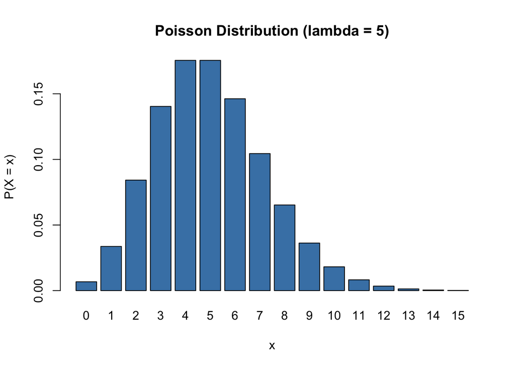

```r
# Poisson with mean (lambda) = 5
barplot(dpois(0:15, 5), names.arg = 0:15,
        main = "Poisson Distribution (lambda = 5)",
        xlab = "x", ylab = "P(X = x)", col = "steelblue")
```

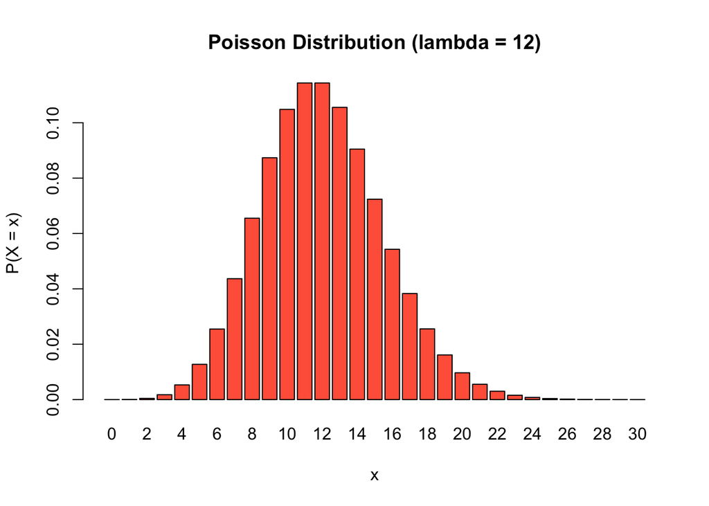

```r
# Poisson with mean (lambda) = 12
barplot(dpois(0:30, 12), names.arg = 0:30,
        main = "Poisson Distribution (lambda = 12)",
        xlab = "x", ylab = "P(X = x)", col = "tomato")
```

## Normal Distribution

The **Normal (Gaussian) distribution** is the famous “bell curve”. It’s defined by two parameters:

- **Mean (μ)** — the centre of the bell.
- **Standard deviation (σ)** — how spread out the bell is. A small σ gives a tall, narrow bell; a large σ gives a wide, flat one.

The **standard normal** has μ = 0 and σ = 1. Most values fall between −2 and +2.

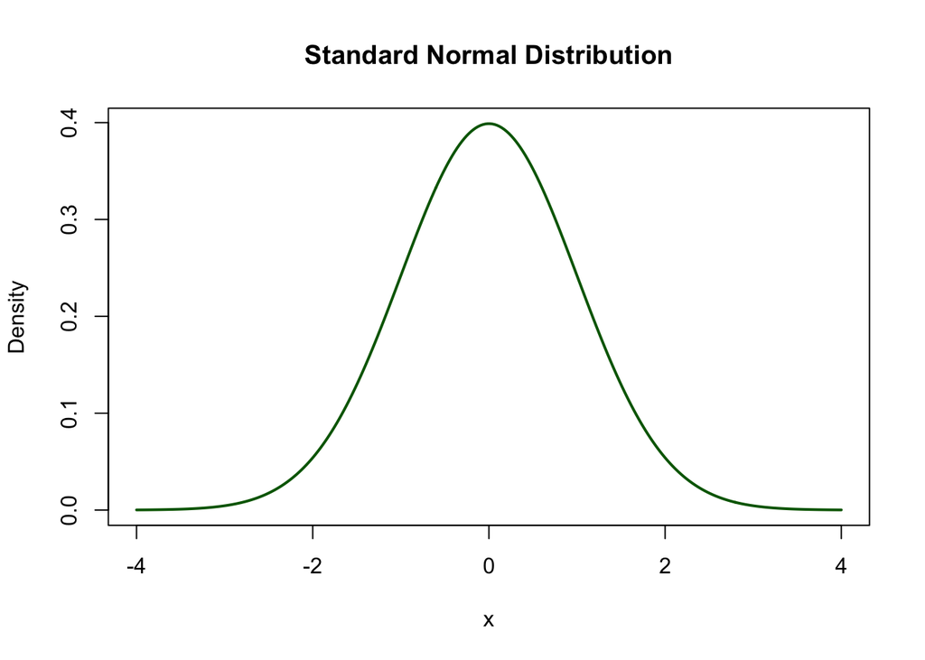

```r
x <- seq(-4, 4, length.out = 300)
plot(x, dnorm(x, mean = 0, sd = 1), type = "l", lwd = 2, col = "darkgreen",
     main = "Standard Normal Distribution",
     xlab = "x", ylab = "Density")
```

## Gamma Distribution

The **Gamma distribution** is used for things that are always positive and often skewed right — like *waiting times* (e.g., how long until the next bus arrives).

- It has two parameters: **shape** (controls the curve’s peakiness) and **rate** (controls how stretched it is).

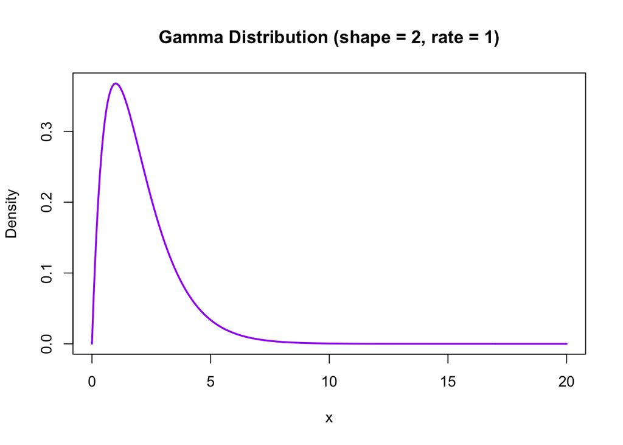

```r
x <- seq(0, 20, length.out = 300)
plot(x, dgamma(x, shape = 2, rate = 1), type = "l", lwd = 2, col = "purple",
     main = "Gamma Distribution (shape = 2, rate = 1)",
     xlab = "x", ylab = "Density")
```

## Chi-Squared Distribution

The **Chi-squared (χ²) distribution** pops up a lot in hypothesis testing (we’ll use it in Section 4). It has one parameter, **degrees of freedom (df)**, which controls its shape.

- With a small df (e.g. 2), the curve is highly right-skewed.
- As df increases, the curve becomes more symmetric and starts to look like a Normal distribution.

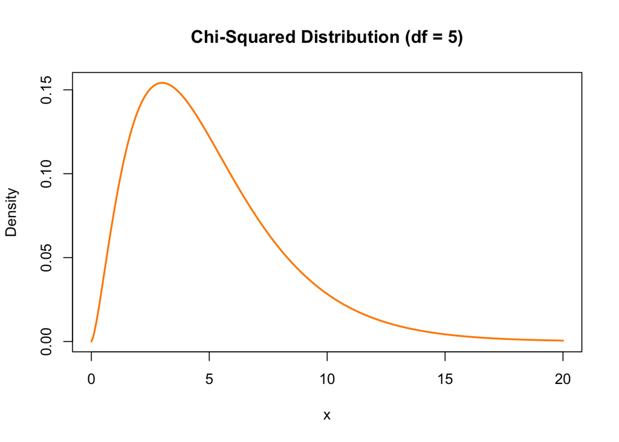

```r
x <- seq(0, 20, length.out = 300)
plot(x, dchisq(x, df = 5), type = "l", lwd = 2, col = "darkorange",
     main = "Chi-Squared Distribution (df = 5)",
     xlab = "x", ylab = "Density")
```

# 2. Hypothesis Testing — The Big Picture

Hypothesis testing is like a **courtroom trial for data**:

| Courtroom analogy | Statistics equivalent |
| --- | --- |
| The defendant is “innocent until proven guilty” | We start by assuming the **null hypothesis** ($H_0$) is true — nothing special is going on |
| The prosecution presents evidence | We collect data and compute a **test statistic** |
| The jury decides: is the evidence strong enough? | We look at the **p-value** — how surprising our data would be *if $H_0$ were true* |
| Verdict: guilty or not guilty | We **reject** $H_0$ (evidence is strong) or **fail to reject** $H_0$ (evidence isn’t strong enough) |

### Step-by-step recipe for every hypothesis test

Every single test in this lab follows the same 6 steps:

1. **State the hypotheses.** Write down $H_0$ (the boring “nothing is happening” claim) and $H_1$ (the interesting claim you want to check).
2. **Choose a significance level** $\alpha$ (almost always **0.05**, which means we’re willing to accept a 5% chance of wrongly rejecting $H_0$).
3. **Check assumptions.** Different tests have different requirements (e.g., “data must be approximately normal”). We check these with plots and formal tests.
4. **Pick the right test.** Based on our assumptions:
   - Data looks normal? → Use a **parametric test** (like a t-test). These are more powerful when assumptions are met.
   - Data doesn’t look normal, or the sample is very small? → Use a **non-parametric test** (like the Wilcoxon test). These make fewer assumptions and are safer.
5. **Run the test in R** and look at the **p-value** in the output.
6. **Make a conclusion:**
   - **p-value < 0.05** → Reject $H_0$. The evidence is strong enough to support $H_1$.
   - **p-value ≥ 0.05** → Fail to reject $H_0$. We don’t have enough evidence to support $H_1$ (but this does NOT prove $H_0$ is true!).

*Sections 3–5 below walk through this recipe on many different examples.*

# 3. Smaller Tests

## 3.1 Study Time Before and After Intervention

### The scenario

A study-skills workshop claims to improve student study habits. **Ten students** recorded their weekly study hours **before** and **after** the workshop. We want to check: did the workshop actually increase study time?

### Setting up the hypotheses

- $\mu_1$ = mean hours **before** the workshop
- $\mu_2$ = mean hours **after** the workshop

$$H_0: \mu_1 \geq \mu_2 \quad
\text{(workshop made no improvement — or even made it worse)}$$
$$H_1: \mu_1 < \mu_2 \quad \text{(workshop
improved study time)}$$
$$\alpha =
0.05$$

### Why is this “paired” data?

Because the **same 10 students** were measured twice (before and after). Their results are *linked*. We don’t compare group A to group B — we compare each student to *themselves*. This means we work with the **differences** (before − after) for each student.

### Checking assumptions

We need to check if these differences are roughly normally distributed. We’ll use:

- A **Q-Q plot** (if the dots follow the red line, the data is approximately normal).
- The **Shapiro-Wilk test** (if the p-value > 0.05, we have no strong evidence against normality).

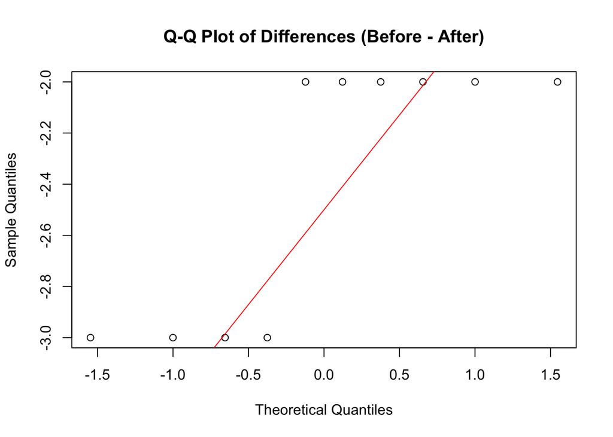

```r
before <- c(12, 15, 10, 18, 14, 11, 16, 13, 17, 12)
after  <- c(15, 18, 13, 20, 16, 14, 18, 15, 19, 14)

diff <- before - after

# Check normality of differences
qqnorm(diff, main = "Q-Q Plot of Differences (Before - After)")
qqline(diff, col = "red")
```

```r
shapiro.test(diff)
```

```
##
##  Shapiro-Wilk normality test
##
## data:  diff
## W = 0.64049, p-value = 0.0001687
```

### Choosing the test

The Q-Q plot shows some wobble and the sample is very small (only 10 students), so we play it safe and use the **Wilcoxon signed-rank test**. This is the **non-parametric version of a paired t-test** — it doesn’t need the data to be perfectly normal.

- `paired = TRUE` tells R these are paired (matched) observations.
- `alternative = "less"` tells R we’re testing whether `before` is *less than* `after`.

```r
wilcox.test(before, after, alternative = "less", paired = TRUE)
```

```
##
##  Wilcoxon signed rank test with continuity correction
##
## data:  before and after
## V = 0, p-value = 0.002283
## alternative hypothesis: true location shift is less than 0
```

### How to read the output

Look at the **p-value** in the output above.

- **If p-value < 0.05:** We reject $H_0$ and conclude that the workshop **significantly increased** study time. 🎉
- **If p-value ≥ 0.05:** We fail to reject $H_0$ — we don’t have strong enough evidence that the workshop helped.

## 3.2 Mobile-Phone Usage

### The scenario

Someone claims that students use their mobile phones for **more than 5 hours per week** on average. We surveyed **26 students** and recorded their weekly phone usage (in hours). Let’s test this claim.

### Setting up the hypotheses

$$H_0: \mu \leq 5 \quad \text{(average
usage is 5 hours or less)}$$
$$H_1:
\mu > 5 \quad \text{(average usage IS more than 5 hours)}$$
$$\alpha = 0.05$$

### Checking assumptions

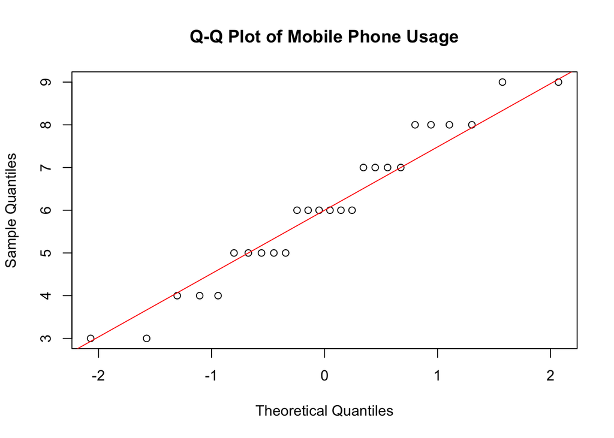

```r
x <- c(6, 4, 8, 7, 5, 6, 9, 3, 5, 7, 4, 6, 8, 5, 7,
       6, 4, 9, 5, 8, 3, 6, 5, 7, 6, 8)

# Check normality
qqnorm(x, main = "Q-Q Plot of Mobile Phone Usage")
qqline(x, col = "red")
```

```r
shapiro.test(x)
```

```
##
##  Shapiro-Wilk normality test
##
## data:  x
## W = 0.95537, p-value = 0.3086
```

### Choosing the test

- `mu = 5` tells R to test against the claimed average of 5 hours.
- `alternative = "greater"` tells R we’re checking if the true average is *greater* than 5.

```r
wilcox.test(x, mu = 5, alternative = "greater")
```

```
##
##  Wilcoxon signed rank test with continuity correction
##
## data:  x
## V = 191, p-value = 0.004144
## alternative hypothesis: true location is greater than 5
```

### How to read the output

- **p-value < 0.05** → Reject $H_0$. Average phone usage is significantly more than 5 hours.
- **p-value ≥ 0.05** → Fail to reject $H_0$. Not enough evidence to confirm the claim.

## 3.3 Compare Schools

### The scenario

We have exam scores from two **different** schools (School A and School B). We want to know: is there a **significant difference** in mean scores between the two schools?

### Setting up the hypotheses

$$H_0: \mu_A = \mu_B \quad \text{(no
difference in mean scores)}$$
$$H_1:
\mu_A \neq \mu_B \quad \text{(there IS a difference)}$$
$$\alpha = 0.05$$

> **Note:** This is a “two-tailed” test (≠) because we’re not predicting *which* school is better — just whether they differ.

### Checking assumptions

```r
school_A <- c(78, 85, 90, 76, 82, 79, 88, 91, 85, 80, 83, 87, 92, 84, 81)
school_B <- c(82, 88, 84, 79, 85, 83, 87, 90, 86, 81, 85, 89, 91, 87, 83)

# Check normality
shapiro.test(school_A)
```

```
##
##  Shapiro-Wilk normality test
##
## data:  school_A
## W = 0.97334, p-value = 0.9041
```

```r
shapiro.test(school_B)
```

```
##
##  Shapiro-Wilk normality test
##
## data:  school_B
## W = 0.98593, p-value = 0.9949
```

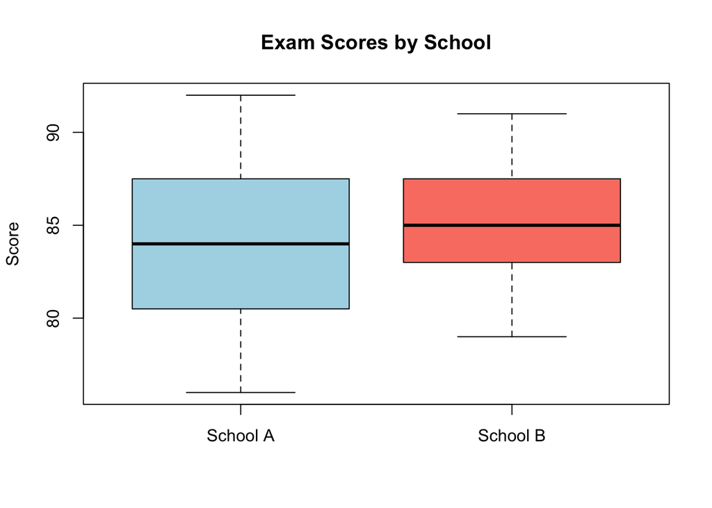

```r
# Boxplot for a visual comparison
boxplot(school_A, school_B,
        names = c("School A", "School B"),
        col = c("lightblue", "salmon"),
        main = "Exam Scores by School",
        ylab = "Score")
```

### Choosing the test

Both groups look approximately normal (Shapiro-Wilk p-values > 0.05) and their spreads are similar (the boxplots are roughly the same width). So we can use a **two-sample t-test** with `var.equal = TRUE` (this means we’re assuming equal variances).

- This is an **independent** (unpaired) test because the students in School A are *different people* from those in School B.

```r
t.test(school_A, school_B, var.equal = TRUE)
```

```
##
##  Two Sample t-test
##
## data:  school_A and school_B
## t = -0.82564, df = 28, p-value = 0.416
## alternative hypothesis: true difference in means is not equal to 0
## 95 percent confidence interval:
##  -4.409254  1.875920
## sample estimates:
## mean of x mean of y
##  84.06667  85.33333
```

### How to read the output

- **p-value < 0.05** → Reject $H_0$. The two schools have significantly different mean scores.
- **p-value ≥ 0.05** → Fail to reject $H_0$. No significant difference detected.

## 3.4 Placebo vs Drug

### The scenario

A pharmaceutical company claims their drug lowers blood pressure more than a placebo (a “sugar pill” with no active ingredient). We recorded the **blood pressure reduction** (in mmHg) for patients in two groups: one group took the drug, the other took the placebo.

### Setting up the hypotheses

$$H_0: \mu_{\text{drug}} \leq
\mu_{\text{placebo}} \quad \text{(drug is no better than
placebo)}$$
$$H_1: \mu_{\text{drug}}
> \mu_{\text{placebo}} \quad \text{(drug reduces BP more than
placebo)}$$
$$\alpha =
0.05$$

### Checking assumptions

```r
drug_group    <- c(8.1, 7.6, 8.9, 9.2, 7.8, 8.3, 9.1, 8.7, 9.0, 8.5, 8.6, 9.3)
placebo_group <- c(4.5, 10.2, 3.8, 12.1, 4.0, 11.3, 3.9, 10.8, 5.2, 9.7)

# Check normality
shapiro.test(drug_group)
```

```
##
##  Shapiro-Wilk normality test
##
## data:  drug_group
## W = 0.94814, p-value = 0.61
```

```r
shapiro.test(placebo_group)
```

```
##
##  Shapiro-Wilk normality test
##
## data:  placebo_group
## W = 0.81316, p-value = 0.02094
```

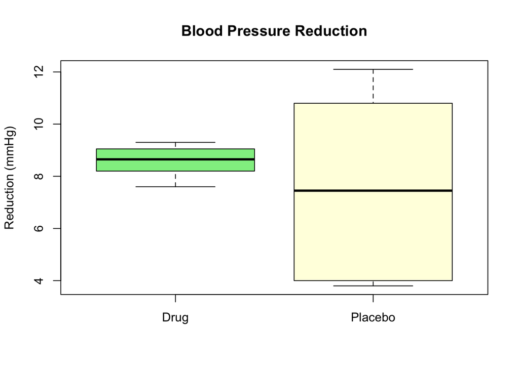

```r
# Check variances visually
boxplot(drug_group, placebo_group,
        names = c("Drug", "Placebo"),
        col = c("lightgreen", "lightyellow"),
        main = "Blood Pressure Reduction",
        ylab = "Reduction (mmHg)")
```

### Choosing the test

When variances are unequal, we use **Welch’s t-test** (set `var.equal = FALSE`). Welch’s t-test adjusts the degrees of freedom to account for the different spreads.

```r
t.test(drug_group, placebo_group, alternative = "greater", var.equal = FALSE)
```

```
##
##  Welch Two Sample t-test
##
## data:  drug_group and placebo_group
## t = 0.92527, df = 9.3683, p-value = 0.189
## alternative hypothesis: true difference in means is greater than 0
## 95 percent confidence interval:
##  -1.012856       Inf
## sample estimates:
## mean of x mean of y
##  8.591667  7.550000
```

### How to read the output

- **p-value < 0.05** → Reject $H_0$. The drug produces a significantly greater blood pressure reduction than the placebo.
- **p-value ≥ 0.05** → Fail to reject $H_0$. Not enough evidence that the drug is better.

## 3.5 Penalty Shoot-Outs

### The scenario

Does the team that shoots **first** in a World Cup penalty shoot-out have an advantage? In 160 shoot-outs (80 per team), the team shooting first scored **45** penalties while the team shooting second scored **35**. Is this difference statistically significant?

### Setting up the hypotheses

- $p_1$ = success rate for the team shooting first
- $p_2$ = success rate for the team shooting second

$$H_0: p_1 \leq p_2 \quad \text{(no
first-mover advantage)}$$
$$H_1: p_1
> p_2 \quad \text{(first-mover advantage exists)}$$
$$\alpha = 0.05$$

### Choosing the test

Here we’re comparing **proportions** (success rates), not means. R’s `prop.test()` does this for us:

- We pass in the number of successes and the total number of attempts for each group.
- `alternative = "greater"` tells R we’re testing if the first proportion is *higher*.

```r
successes      <- c(45, 35)
total_attempts <- c(80, 80)

prop.test(successes, total_attempts, alternative = "greater")
```

```
##
##  2-sample test for equality of proportions with continuity correction
##
## data:  successes out of total_attempts
## X-squared = 2.025, df = 1, p-value = 0.07736
## alternative hypothesis: greater
## 95 percent confidence interval:
##  -0.01651718  1.00000000
## sample estimates:
## prop 1 prop 2
## 0.5625 0.4375
```

### How to read the output

- **p-value < 0.05** → Reject $H_0$. There IS a significant first-mover advantage.
- **p-value ≥ 0.05** → Fail to reject $H_0$. No significant evidence of an advantage.

## 3.6 Two Surveys

### The scenario

Two surveys asked respondents whether they supported a new government policy.

- **Survey 1:** 45 out of 80 people said “Yes” (56.25%)
- **Survey 2:** 56 out of 103 people said “Yes” (54.37%)

Is there a significant **difference** between these two proportions?

### Setting up the hypotheses

$$H_0: p_1 = p_2 \quad \text{(both surveys
show the same level of support)}$$
$$H_1: p_1 \neq p_2 \quad \text{(the levels of
support differ)}$$
$$\alpha =
0.05$$

### Running the test

Again, we use `prop.test()` because we’re comparing two proportions. This time `alternative = "two.sided"` because we’re just checking if they *differ* (we don’t care which is bigger).

```r
prop.test(c(45, 56), c(80, 103), alternative = "two.sided")
```

```
##
##  2-sample test for equality of proportions with continuity correction
##
## data:  c(45, 56) out of c(80, 103)
## X-squared = 0.010813, df = 1, p-value = 0.9172
## alternative hypothesis: two.sided
## 95 percent confidence interval:
##  -0.1374478  0.1750692
## sample estimates:
##    prop 1    prop 2
## 0.5625000 0.5436893
```

### How to read the output

- **p-value < 0.05** → Reject $H_0$. The two surveys show significantly different levels of support.
- **p-value ≥ 0.05** → Fail to reject $H_0$. The difference isn’t statistically significant — it could just be due to chance.

# 4. Chi-Squared Tests

Chi-squared tests are used when your data is **categorical** (groups / categories) rather than numerical. There are two main types:

| Type | What it tests | Example |
| --- | --- | --- |
| **Goodness-of-fit** | Does the distribution of one categorical variable match what we expected? | “Is this die fair?” |
| **Test of independence** | Are two categorical variables related, or are they independent? | “Is shirt colour related to survival?” |

## 4.1 Dice Rolls

### The scenario

You rolled a die **150 times** and recorded how often each face appeared:

| Face | 1 | 2 | 3 | 4 | 5 | 6 |
| --- | --- | --- | --- | --- | --- | --- |
| Count | 22 | 21 | 22 | 27 | 22 | 36 |

If the die were **perfectly fair**, we’d expect each face to appear 150 ÷ 6 = **25 times**. Face 6 appeared 36 times — is that just bad luck, or is the die actually loaded?

### Setting up the hypotheses

$$H_0: \text{The die is fair (each face
has probability } \frac{1}{6}\text{)}$$
$$H_1: \text{The die is NOT fair (at least one face
has a different probability)}$$
$$\alpha = 0.05$$

### Running the chi-squared goodness-of-fit test

We give `chisq.test()` our observed counts and the expected probabilities. The red dashed line on the bar plot shows the expected count (25) for a fair die.

```r
observed <- c(22, 21, 22, 27, 22, 36)
expected <- rep(1/6, 6)

chisq.test(observed, p = expected)
```

```
##
##  Chi-squared test for given probabilities
##
## data:  observed
## X-squared = 6.72, df = 5, p-value = 0.2423
```

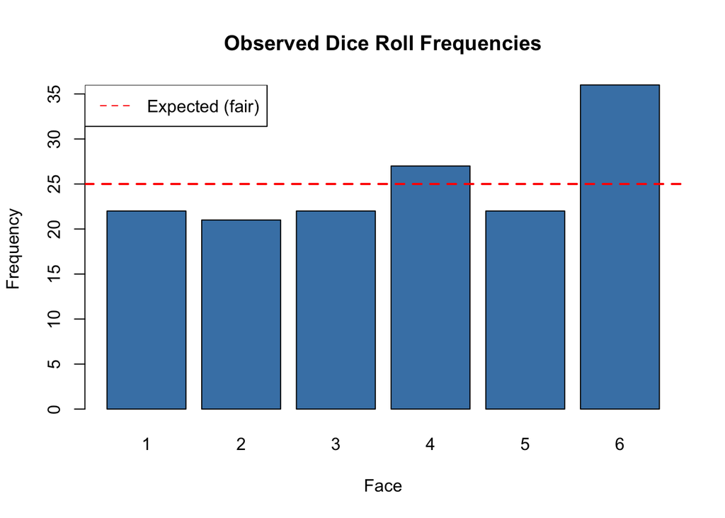

```r
barplot(observed, names.arg = 1:6,
        col = "steelblue",
        main = "Observed Dice Roll Frequencies",
        xlab = "Face", ylab = "Frequency")
abline(h = 150/6, col = "red", lty = 2, lwd = 2)
legend("topleft", legend = "Expected (fair)", col = "red", lty = 2)
```

### How to read the output

- **p-value < 0.05** → Reject $H_0$. The die is likely **not fair**.
- **p-value ≥ 0.05** → Fail to reject $H_0$. There isn’t enough evidence to say the die is unfair — the variation we see could be due to chance.

## 4.2 Letter Distribution

### The scenario

In a sample of text, letters were grouped into 5 categories, and we counted how many fell into each group:

| Group | 1 | 2 | 3 | 4 | 5 |
| --- | --- | --- | --- | --- | --- |
| Observed count | 100 | 110 | 80 | 55 | 14 |

Based on typical English letter frequencies, the **expected proportions** for these groups are 29%, 21%, 17%, 17%, and 16%. Does our text match this pattern, or is it unusual?

### Setting up the hypotheses

$$H_0: \text{The letter frequencies match
typical English}$$
$$H_1: \text{The
letter frequencies do NOT match typical English}$$
$$\alpha = 0.05$$

### Running the test

```r
observed_letters  <- c(100, 110, 80, 55, 14)
expected_props    <- c(0.29, 0.21, 0.17, 0.17, 0.16)

chisq.test(observed_letters, p = expected_props)
```

```
##
##  Chi-squared test for given probabilities
##
## data:  observed_letters
## X-squared = 55.395, df = 4, p-value = 2.685e-11
```

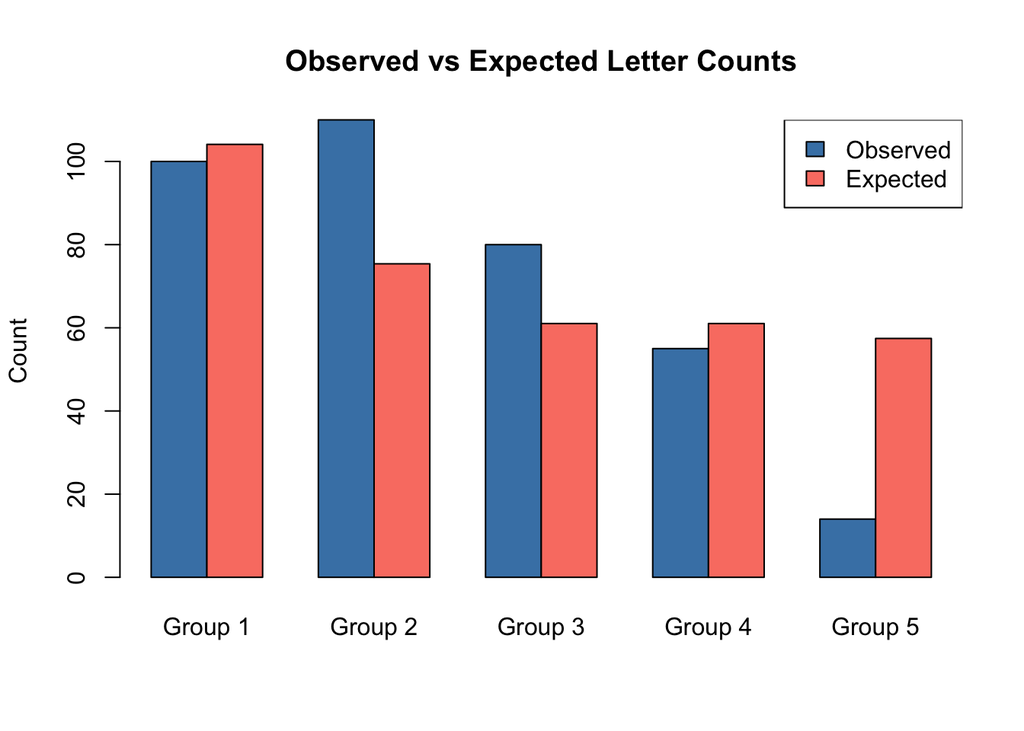

```r
barplot(rbind(observed_letters, expected_props * sum(observed_letters)),
        beside = TRUE,
        col = c("steelblue", "salmon"),
        names.arg = paste("Group", 1:5),
        main = "Observed vs Expected Letter Counts",
        ylab = "Count")
legend("topright", legend = c("Observed", "Expected"), fill = c("steelblue", "salmon"))
```

### How to read the output

- **p-value < 0.05** → Reject $H_0$. This text does NOT follow typical English letter frequencies (perhaps it’s from a different language, or encoded in some way).
- **p-value ≥ 0.05** → Fail to reject $H_0$. The text looks consistent with normal English.

## 4.3 Star Trek

### The scenario

In Star Trek, crew members wear uniforms of different colours: **Blue**, **Gold**, or **Red**. There’s a famous joke that “red-shirt” crew members die more often. Let’s test this with actual data!

|  | Alive | Dead |
| --- | --- | --- |
| Blue | 135 | 10 |
| Gold | 19 | 10 |
| Red | 215 | 46 |

We want to know: **Is uniform colour associated with whether a crew member dies?** (Or are deaths spread evenly across all colours?)

### Setting up the hypotheses

$$H_0: \text{Uniform colour and survival
are independent (no relationship)}$$
$$H_1: \text{Uniform colour and survival ARE
associated}$$
$$\alpha =
0.05$$

### Running the chi-squared test of independence

When we have a table like this (rows = one category, columns = another), we use a **chi-squared test of independence**. We pass the entire table into `chisq.test()`.

```r
star_trek <- matrix(c(135, 10,
                       19, 10,
                      215, 46),
                    nrow = 3, byrow = TRUE)
rownames(star_trek) <- c("Blue", "Gold", "Red")
colnames(star_trek) <- c("Alive", "Dead")

print(star_trek)
```

```
##      Alive Dead
## Blue   135   10
## Gold    19   10
## Red    215   46
```

```r
chisq.test(star_trek)
```

```
##
##  Pearson's Chi-squared test
##
## data:  star_trek
## X-squared = 17.338, df = 2, p-value = 0.0001719
```

### How to read the output

- **p-value < 0.05** → Reject $H_0$. Uniform colour **IS** associated with survival (the “red-shirt effect” has statistical backing! 👀).
- **p-value ≥ 0.05** → Fail to reject $H_0$. No significant association — deaths are spread roughly evenly across colours.

## 4.4 Belts

### The scenario

Is there a relationship between **seat-belt use** and **injury severity** in car accidents?

|  | No Injury | Minor | Serious |
| --- | --- | --- | --- |
| No Belt | 100 | 50 | 20 |
| Belt (lap only) | 80 | 40 | 30 |
| Belt (full) | 60 | 30 | 40 |

### Setting up the hypotheses

$$H_0: \text{Belt usage and injury
severity are independent (not related)}$$
$$H_1: \text{Belt usage and injury severity ARE
associated}$$
$$\alpha =
0.05$$

### Running the test

```r
belts <- matrix(c(100, 50, 20,
                   80, 40, 30,
                   60, 30, 40),
                nrow = 3, byrow = TRUE)
rownames(belts) <- c("No Belt", "Lap Belt", "Full Belt")
colnames(belts) <- c("No Injury", "Minor", "Serious")

print(belts)
```

```
##           No Injury Minor Serious
## No Belt         100    50      20
## Lap Belt         80    40      30
## Full Belt        60    30      40
```

```r
chisq.test(belts)
```

```
##
##  Pearson's Chi-squared test
##
## data:  belts
## X-squared = 16.629, df = 4, p-value = 0.002282
```

### How to read the output

- **p-value < 0.05** → Reject $H_0$. Belt usage IS significantly associated with injury severity. (In this data, interestingly, the “full belt” category doesn’t always align with what you’d expect — think about why that might be!)
- **p-value ≥ 0.05** → Fail to reject $H_0$. No significant association detected.

# 5. Tests Using Datasets

In the previous section we typed our data directly into R. In practice, data usually comes from **CSV files** or other datasets. This section shows how to load data from files and apply the same testing logic.

## 5.1 Differences Between Origins (Car MPG Data)

### The scenario

We have a dataset of cars with their fuel efficiency (**MPG** = miles per gallon) and the car’s **country of origin** (USA, Europe, or Japan). We want to know: **Do cars from different countries have significantly different fuel efficiency?**

### Setting up the hypotheses

For each pair of countries (e.g., USA vs Japan):

$$H_0: \mu_{\text{group1}} =
\mu_{\text{group2}} \quad \text{(no difference in mean MPG)}$$
$$H_1: \mu_{\text{group1}} \neq
\mu_{\text{group2}} \quad \text{(there IS a difference)}$$
$$\alpha = 0.05$$

### Running the tests

We compare all three pairs: USA vs Japan, USA vs Europe, and Europe vs Japan. This is called **pairwise comparison**.

> **Note:** This code chunk is set to `eval=FALSE` because it requires the `auto-mpg.data` file to be in your working directory. If you have that file, change `eval=FALSE` to `eval=TRUE` in the chunk header to run it.

```r
# Note: requires the auto-mpg.data file in the working directory
auto_data <- read.table("auto-mpg.data", header = TRUE, na.strings = "?")
auto_data$origin <- factor(auto_data$origin,
                           levels = c(1, 2, 3),
                           labels = c("USA", "Europe", "Japan"))

usa_mpg    <- auto_data$mpg[auto_data$origin == "USA"]
europe_mpg <- auto_data$mpg[auto_data$origin == "Europe"]
japan_mpg  <- auto_data$mpg[auto_data$origin == "Japan"]

# Visualise
boxplot(mpg ~ origin, data = auto_data,
        col = c("lightblue", "lightgreen", "lightyellow"),
        main = "MPG by Country of Origin",
        ylab = "Miles per Gallon")

# Pairwise t-tests
cat("--- USA vs Japan ---\n")
t.test(usa_mpg, japan_mpg)

cat("--- USA vs Europe ---\n")
t.test(usa_mpg, europe_mpg)

cat("--- Europe vs Japan ---\n")
t.test(europe_mpg, japan_mpg)
```

### How to read the output

For each comparison, check the p-value:

- **p-value < 0.05** → The two countries have significantly different mean MPG.
- **p-value ≥ 0.05** → No significant difference between those two countries.

## 5.2 Difference in Marks (English vs Math)

### The scenario

We have a dataset (`SampleDataset2014.csv`) containing students’ **English** and **Math** marks. We want to know: do students score significantly differently in English compared to Math?

This is **paired data** because the same students took both subjects — we’re comparing each student’s English score to their *own* Math score.

### Setting up the hypotheses

$$H_0: \mu_{\text{English}} =
\mu_{\text{Math}} \quad \text{(no difference in average marks)}$$
$$H_1: \mu_{\text{English}} \neq
\mu_{\text{Math}} \quad \text{(there IS a difference)}$$
$$\alpha = 0.05$$

### Running the test

We first remove any students who are missing either their English or Math score, then check whether the **differences** (English − Math) are normally distributed, and finally run a **paired t-test**.

```r
marks_data <- read.csv("SampleDataset2014.csv")

# Keep only rows where both English and Math are available
marks_filtered <- marks_data[!is.na(marks_data$English) & !is.na(marks_data$Math), ]

cat("Number of complete cases:", nrow(marks_filtered), "\n")
```

```
## Number of complete cases: 398
```

```r
# Summary stats
cat("\nEnglish - Mean:", mean(marks_filtered$English),
    "SD:", sd(marks_filtered$English), "\n")
```

```
##
## English - Mean: 82.7441 SD: 6.844801
```

```r
cat("Math    - Mean:", mean(marks_filtered$Math),
    "SD:", sd(marks_filtered$Math),    "\n")
```

```
## Math    - Mean: 65.44683 SD: 8.462137
```

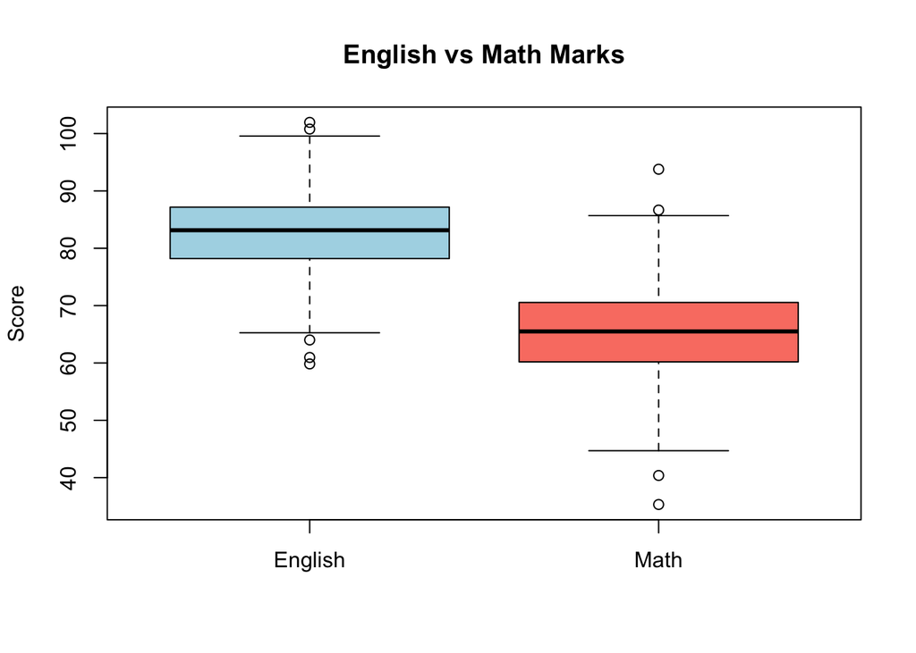

```r
# Visualise
boxplot(marks_filtered[, c("English", "Math")],
        col = c("lightblue", "salmon"),
        main = "English vs Math Marks",
        ylab = "Score")
```

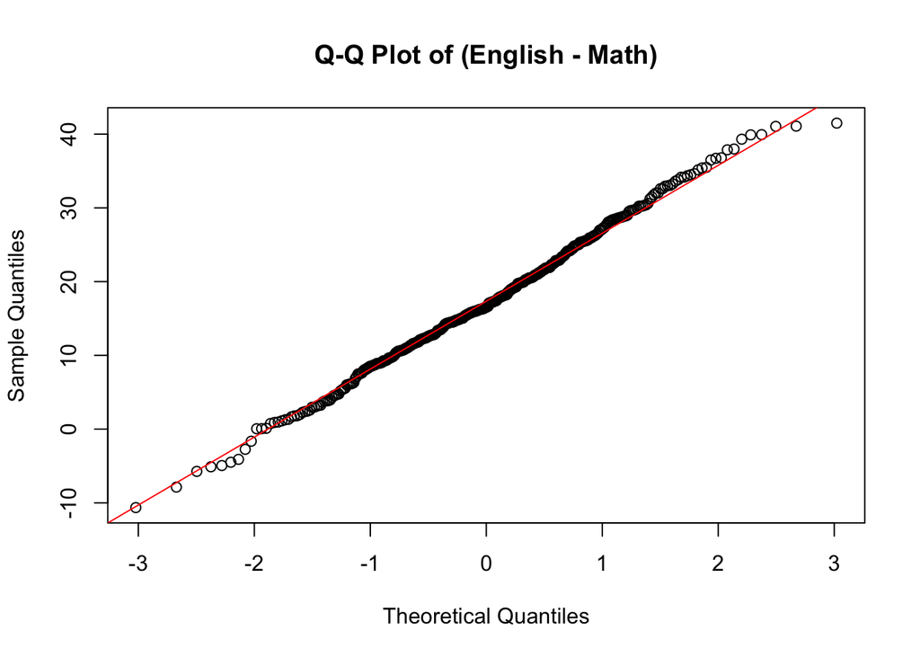

```r
# Check normality of differences
diff_marks <- marks_filtered$English - marks_filtered$Math
qqnorm(diff_marks, main = "Q-Q Plot of (English - Math)")
qqline(diff_marks, col = "red")
```

```r
shapiro.test(diff_marks)
```

```
##
##  Shapiro-Wilk normality test
##
## data:  diff_marks
## W = 0.99667, p-value = 0.5858
```

```r
# Paired t-test
t.test(marks_filtered$English, marks_filtered$Math, paired = TRUE)
```

```
##
##  Paired t-test
##
## data:  marks_filtered$English and marks_filtered$Math
## t = 36.313, df = 397, p-value < 2.2e-16
## alternative hypothesis: true mean difference is not equal to 0
## 95 percent confidence interval:
##  16.36079 18.23373
## sample estimates:
## mean difference
##        17.29726
```

### How to read the output

- **p-value < 0.05** → Reject $H_0$. Students score significantly differently in English vs Math.
- **p-value ≥ 0.05** → Fail to reject $H_0$. No significant difference between the two subjects.

## 5.3 Five Surveys — Smokers

### The scenario

A group of smokers recorded the number of **cigarettes smoked per day** before and after an anti-smoking intervention. We want to know: did the intervention actually reduce smoking?

### Setting up the hypotheses

$$H_0: \mu_{\text{Before}} \leq
\mu_{\text{After}} \quad \text{(intervention had no effect — or made it
worse)}$$
$$H_1: \mu_{\text{Before}}
> \mu_{\text{After}} \quad \text{(intervention reduced
smoking)}$$
$$\alpha =
0.05$$

### Running the test

This is **paired data** again (same people measured before and after), so we use a **paired t-test** with `alternative = "greater"` (we’re testing if “Before” values are *greater than* “After” values, which would mean smoking decreased).

> **Note:** This chunk requires `Smokers.csv` in your working directory. If you don’t have it, change `eval=FALSE` in the chunk header.

```r
# Note: requires the Smokers.csv file in the working directory
smokers_data <- read.csv("Smokers.csv")

cat("Column names:", names(smokers_data), "\n")
head(smokers_data)

# Visualise
boxplot(smokers_data[, c("Before", "After")],
        col = c("tomato", "lightgreen"),
        main = "Cigarettes per Day: Before vs After Intervention",
        ylab = "Cigarettes per Day")

# Check normality of differences
diff_smoke <- smokers_data$Before - smokers_data$After
shapiro.test(diff_smoke)

# Paired t-test (or Wilcoxon if non-normal)
t.test(smokers_data$Before, smokers_data$After, paired = TRUE, alternative = "greater")
```

### How to read the output

- **p-value < 0.05** → Reject $H_0$. The intervention significantly reduced smoking! 🎉
- **p-value ≥ 0.05** → Fail to reject $H_0$. Not enough evidence that the intervention worked.

# Quick Reference: Which Test Should I Use?

| Situation | Normal data? | Test to use |
| --- | --- | --- |
| One sample vs a known value | Yes | One-sample t-test |
| One sample vs a known value | No | Wilcoxon signed-rank test |
| Two paired samples (same people, before/after) | Yes | Paired t-test |
| Two paired samples | No | Wilcoxon signed-rank test |
| Two independent groups, equal variances | Yes | Two-sample t-test (`var.equal = TRUE`) |
| Two independent groups, unequal variances | Yes | Welch’s t-test (`var.equal = FALSE`) |
| Two independent groups | No | Wilcoxon rank-sum test |
| Comparing proportions | — | `prop.test()` |
| Categorical data (one variable) | — | Chi-squared goodness-of-fit |
| Categorical data (two variables) | — | Chi-squared test of independence |